# From drab to fab

Teaching visualisation via incremental improvements

Mine Çetinkaya-Rundel and Maria Tackett

February 2020

In our September 2014 column titled we wrote about five concrete reasons your students should be learning to analyse data in the reproducible paradigm. One of the reasons we gave was that ``[t]his workflow establishes the norm that data analysis and science in general should be an iterative process". Just like data analysis in general, creating an effective data visualisation is also an iterative process.

It can be very inspirational to share highly polished data visualisations with students. A few of our favourite visualisations to bring to the classroom are text analysis of Donald Trump’s tweets by David Robinbson ([varianceexplained.org/r/trump-tweets](http://varianceexplained.org/r/trump-tweets/)), the Dialect Survey by Joshua Katz (joshkatz.co/dialect.html), and map of America’s weather related disasters by Tim Meko (washingtonpost.com/graphics/2019/national/mapping-disasters). We also love the NY Times series What’s Going on in This Graph? (nytimes.com/column/whats-going-on-in-this-graph) as well as just about any visualisation from the Flowing Data blog by Nathan Yau ([flowingdata.com](https://flowingdata.com/)), The Pudding ([pudding.cool](https://pudding.cool/)), The Functional Art blog by Alberto Cairo ([thefunctionalart.com](http://www.thefunctionalart.com/)), and Chartable ([blog.datawrapper.de](https://blog.datawrapper.de/)). For example, the stories on how the American work day changed over 15 years (flowingdata.com/2019/07/16/how-the-american-work-day-changed-in-15-years) and on gender tropes in film with screen direction (pudding.cool/2017/08/screen-direction) both feature in-depth and enlightening but simple visualisations that tell a meaningful story. We like these examples because their message is clear enough to glean quickly, but one can extract deeper insights by looking at them for a bit longer, a bit more closely.

All of these visualisations share one thing in common – they are incredibly polished. It is possible for a student just starting off to think “well, I could never do that!”. Or perhaps worse, to think that they can, and not get to something as impressive on their first or second try and get discouraged. We believe that it’s important to show students not only the end result, but also the process of building a meaningful data visualisation. This journey can be incredibly educational in its own, as each step of the improvement is an opportunity to teach a new data visualisation or wrangling technique.

In this column we present three examples of ``from drab to fab" type class activities, i.e. improving data visualisations. The first example is on types of staff involved with instruction at American universities and how their distributions have changed over time. We walk through this example in detail, showing some of the code and step-by-step improvements on the visualisations. We then present two more examples of such activities, one on electric skateboards and the other on fisheries. The data for all three examples along with R code to produce the visualisations presented here can be found on the GitHub repository accompanying this column at bit.ly/taking-a-chance.

## The drab

The data come from The American Association of University Professors (AAUP), which is a nonprofit membership association of faculty and other academic professionals. In 2013, the AAUP published a report on Trends in Instructional Staff Employment Status. The plot shown in Figure 1 is very similar to a plot presented in this report.

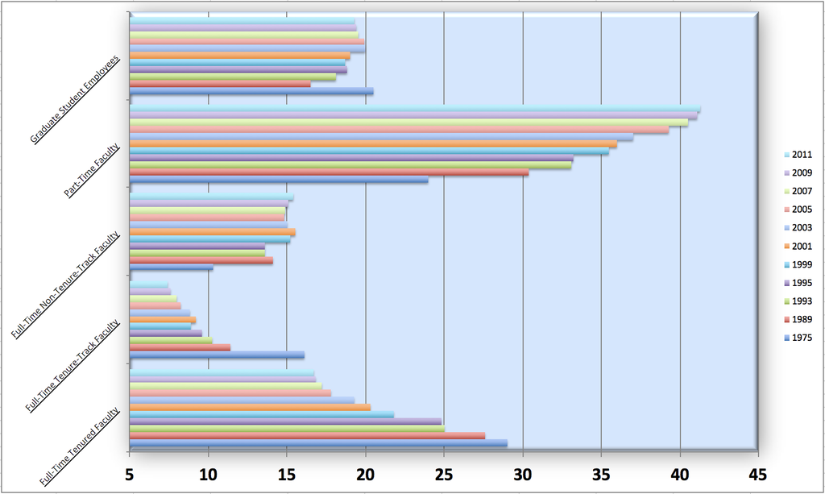

Figure 1: Reproduction of visualisation included in the 2013 AAUP report on titled Trends in Instructional Staff Employment Status

The visualisation is a bit difficult to make sense of, and this is the point. We show this visualisation to the students at the beginning of the class, with some clarification on what the y-axis means (various levels of staff at the university who teach classes, ranging from graduate students to full-time tenured faculty) and ask them to interpret the visualisation in teams. Eventually students are able to identify the main message of the story: the highest proportion of instructors are part-time faculty, and this proportion has been increasing from 1975 to 2011. Along with this main message, students also naturally come to the conclusion that this is not the best visualisation of these data, and in fact, the visualisation hides the main message instead of making it loud and clear.

At this point it’s a worthwhile exercise to ask students to start thinking about how this visualisation can be improved. Instead of just talking through it, we ask students to sketch the visualisations on a piece of paper. They’re not expected to actually create an accurate visualisation via a sketch, but we recommend they label their axes, mark their axis ranges, and decide on which geometric object(s) they plan on using to represent their data (points, lines, bars, etc.). Figure 2 is an example of such a sketch.

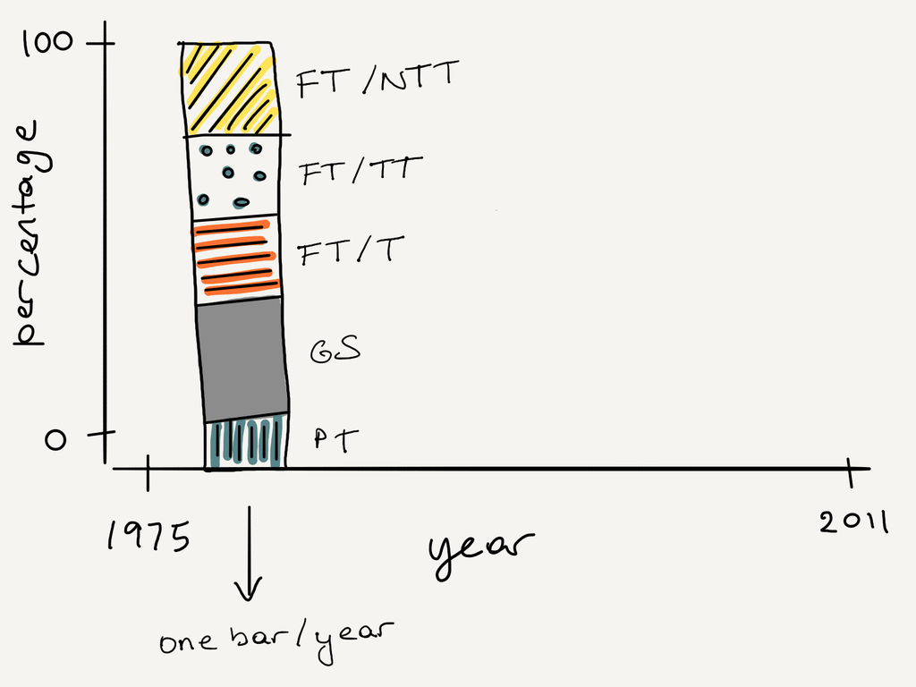

Figure 2: Example of sketch of redesigned visualisation.

Having thought through what the end result should look like, and especially having put it down on paper with a sketch, gives the students a path to follow in the next step when they’re using software to build this improved visualisation.

## Onto the fab

Next we walk through the steps for improving this visualisation. One can do this during class, with interactive exercises and just-in-time teaching sprinkled throughout, or give it as an assignment students work on outside of class. For the latter, we have had success in assigning this as a team exercise in which students write a critique of the original visualization and then create an improved one. After a few days, teams present their visualizations during class while describing how they have improved upon the original one. If the class size allows, it’s also a great idea to then have students present their process (both technical and thought processes) for improving the visualization, so they can see the various approaches each team has taken.

In the walk through of a possible path to “fab” (an improved visualisation) that we present below, we highlight opportunities for instruction along the way, using R as the programming language and the **tidyverse** suite of packages. We also present a series of questions that can be used as part of a class activity or assignment. We deliberately keep steps simple, improving only one or two features of the visualisation at a time, in an effort to emphasize that creating an effective data visualisation is an iterative process. The visualizations in this path is representative of the variety of those created by students across multiple semesters of doing this assignment in introductory data science courses.

### Step 1. Get the data

The dataset provided in the AAUP report is in the following format, and this is exactly how we recommend showing it to the students before distributing it.

| faculty_type | 1975 | 1989 | 1993 | 1995 | 1999 | 2001 | 2003 | 2005 | 2007 | 2009 | 2011 |
| --- | --- | --- | --- | --- | --- | --- | --- | --- | --- | --- | --- |
| Full-Time Tenured Faculty | 29.0 | 27.6 | 25.0 | 24.8 | 21.8 | 20.3 | 19.3 | 17.8 | 17.2 | 16.8 | 16.7 |
| Full-Time Tenure-Track Faculty | 16.1 | 11.4 | 10.2 | 9.6 | 8.9 | 9.2 | 8.8 | 8.2 | 8.0 | 7.6 | 7.4 |
| Full-Time Non-Tenure-Track Faculty | 10.3 | 14.1 | 13.6 | 13.6 | 15.2 | 15.5 | 15.0 | 14.8 | 14.9 | 15.1 | 15.4 |
| Part-Time Faculty | 24.0 | 30.4 | 33.1 | 33.2 | 35.5 | 36.0 | 37.0 | 39.3 | 40.5 | 41.1 | 41.3 |
| Graduate Student Employees | 20.5 | 16.5 | 18.1 | 18.8 | 18.7 | 19.0 | 20.0 | 19.9 | 19.5 | 19.4 | 19.3 |

> **Question 1.** What does each row in the dataset represent? What does each column represent? What do the numbers represent? What does each column add up to, and why?

```r
library(tidyverse)
staff <- read_csv("http://bit.ly/chance-staff")
```

### Step 2. Reshape the data

Remember, our goal is to create a visualisation like the one sketched in Figure 2. In order to do this we need a column for year, a column for percentage, and a column for faculty staff type. However, our dataset is currently not in this format. This presents a great opportunity for some just-in-time teaching for reshaping data from wide to long format. This data wrangling step is quite common when working with time series and with repeated measures data, and hence it’s a useful skill for students to have.

> **Q2.** If the long data will have a row for each year/faculty type combination, and there are 5 faculty types and 11 years of data, how many rows will the data have?

We can accomplish this task using the `pivot_longer()` function, which also has a counterpart `pivot_wider()` for going from long to wide datasets. In the next code chunk we start with the wide dataset and we pivot all of its columns except for faculty type (`cols = -faculty_type`), placing column names in a new variable called `year` and placing the values in the original data frame in a new variable called `percentage`.

```r
staff_long <- staff_wide %>%
  pivot_longer(cols = -faculty_type, names_to = "year", values_to = "percentage")
```

```
## # A tibble: 55 x 3
##   faculty_type              year  percentage
##   <chr>                     <chr>      <dbl>
## 1 Full-Time Tenured Faculty 1975        29
## 2 Full-Time Tenured Faculty 1989        27.6
## 3 Full-Time Tenured Faculty 1993        25
## 4 Full-Time Tenured Faculty 1995        24.8
## 5 Full-Time Tenured Faculty 1999        21.8
## # … with 50 more rows
```

> **Q3.** What does each row represent in the long dataset? How does this differ from what each row represents in the wide dataset?

### Step 3. Recreate the plot

A good way to get started with improving a visualisation is to first recreate it. We can do that by placing `percentage` on the x-axis and `faculty_type` on the y-axis and colouring the bars by the year.

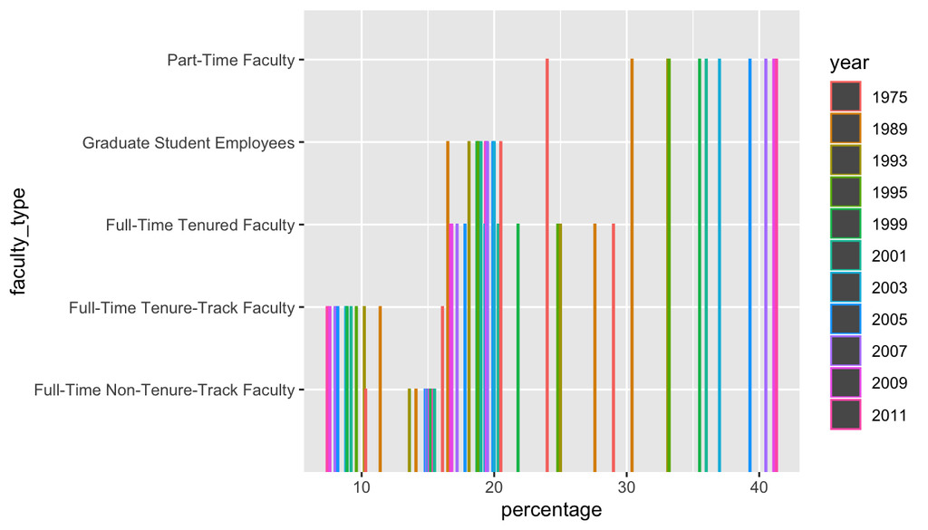

```r
ggplot(data = staff_long, aes(x = percentage, y = faculty_type, color = year)) +
  geom_col(position = "dodge")
```

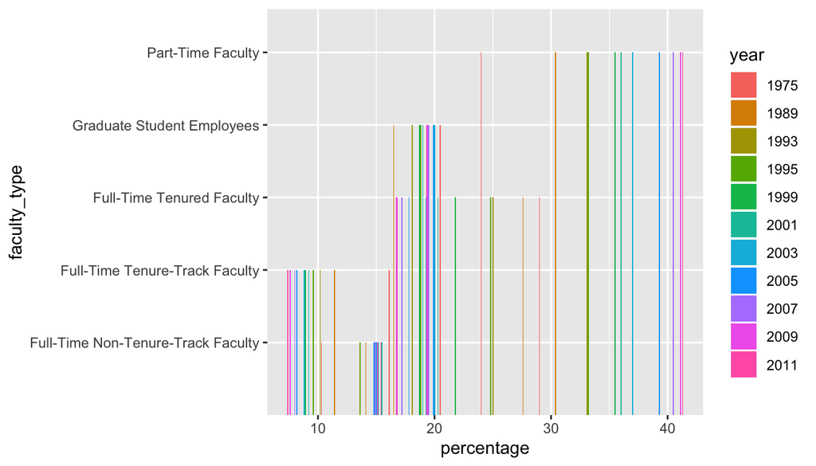

```r
ggplot(data = staff_long, aes(x = percentage, y = faculty_type, fill = year)) +
  geom_col(position = "dodge")
```

That looks better, as in more similar to the original visualisation, but it doesn’t look like the plot we sketched earlier. Our next step is to get closer to that sketch.

### Step 4. Recreate the sketch

We’ll start by changing variable mappings to certain aesthetics of the plot, like the x and y axes and the fill.

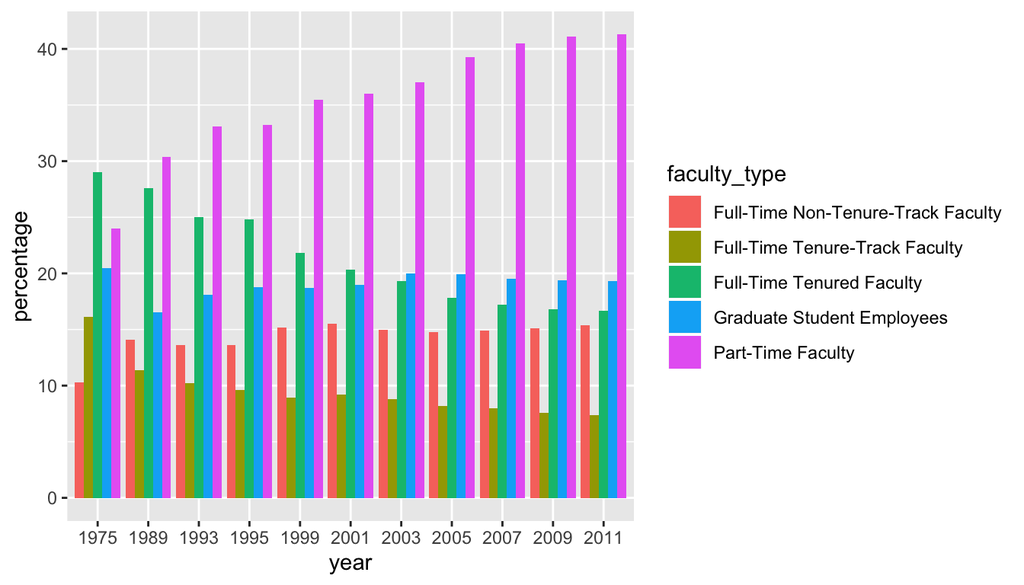

```r
ggplot(data = staff_long, aes(x = year, y = percentage, fill = faculty_type)) +
  geom_col(position = "dodge")
```

> **Q4.** In what way(s) is this plot an improvement on the original “drab” visualization? **Q5.** In what way(s) is the main message still unclear / hidden?

Next, let’s convert it to a segmented bar plot by changing the position of the columns from `dodged` to `fill`. This not only looks like our sketch, but it also is starting to tell the story of increasing percentages of part-time faculty instructional faculty over the years.

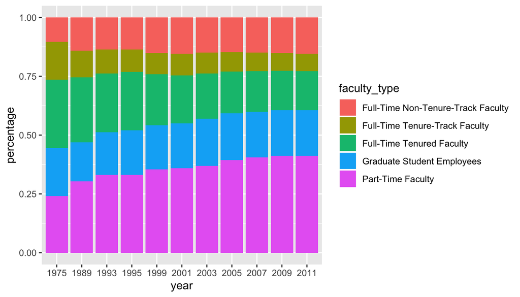

```r
ggplot(data = staff_long, aes(x = year, y = percentage, fill = faculty_type)) +
  geom_col(position = "fill")
```

> **Q6.** In what way(s) is the segmented bar plot an improvement on the the side-by-side bar plot from the previous step? **Q7.** In what way(s) is the main message still unclear / hidden?

### Step 5. Improve further

Most students will get to this point and call it a day once they have successfully created the plot they envisioned in their sketch using R. This presents a good opportunity to get them to think about alternate geometric objects to represent the data. For example, line plots are common in time series data, so they are worth a try.

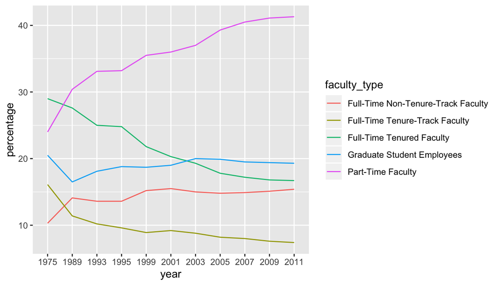

```r
ggplot(staff_long, aes(x = year, y = percentage,
                       group = faculty_type, color = faculty_type)) +
  geom_line()
```

Let’s first transform `year` to be a numerical variable:

```r
staff_long <- staff_long %>%
  mutate(year = as.numeric(year))
```

and then re-plot the data.

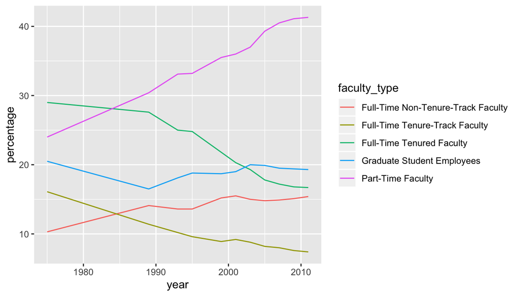

```r
staff_long %>%
  ggplot(aes(x = year, y = percentage,
             group = faculty_type, color = faculty_type)) +
  geom_line()
```

> **Q8.** If the main goal of this visualisation is to draw attention to the increasing percentage of part-time faculty over the years, how can we make this message stronger?

One option is to use colors to draw attention to the part-time faculty line. We can accomplish this by creating a binary variable (`part_time`) that indicates whether the faculty type is part-time or something else. The `fct_other()` function is one quick and straightforward way of accomplishing this. Then, we can use red to indicate part-time and a much more muted colour (grey) to indicate all other categories

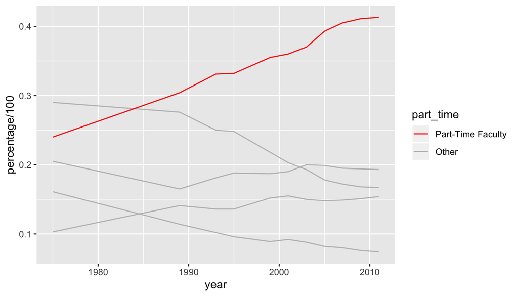

```r
staff_long <- staff_long %>%
  mutate(part_time = fct_other(faculty_type, keep = "Part-Time Faculty"))

ggplot(data = staff_long, aes(x = year, y = percentage/100,
                              group = faculty_type, color = part_time)) +
  geom_line() +
  scale_color_manual(values = c("red", "gray"))
```

Now the main message of the story is clear: the highest proportion of instructors are part-time faculty, and this proportion has been increasing from 1975 to 2011. In the previous line plots, it was unclear where one should focus their attention since each faculty type was a distinct and vibrant colour. By making the lines for the other faculty levels grey, one is still able to see the trends for those faculty types without distracting from the trend of the primary faculty type of interest in this story, part-time faculty.

### Step 6. Formatting and annotation

There are still a number of features of this plot that could use improving:

1. Percentages are missing the % sign (we’ll use the `percent_format()` function from the **scales** package for this)
2. The labels are poorly formatted and the data source is not indicated
3. The grey lines on grey background don’t offer much contrast
4. Legend is taking up too much space on the right hand side

Suppose we store the plot from the previous step as `p`. Then, we can add the necessary layers to `p` to address these updates. We indicted which line of code refers to which update using comments with issue numbers in the code.

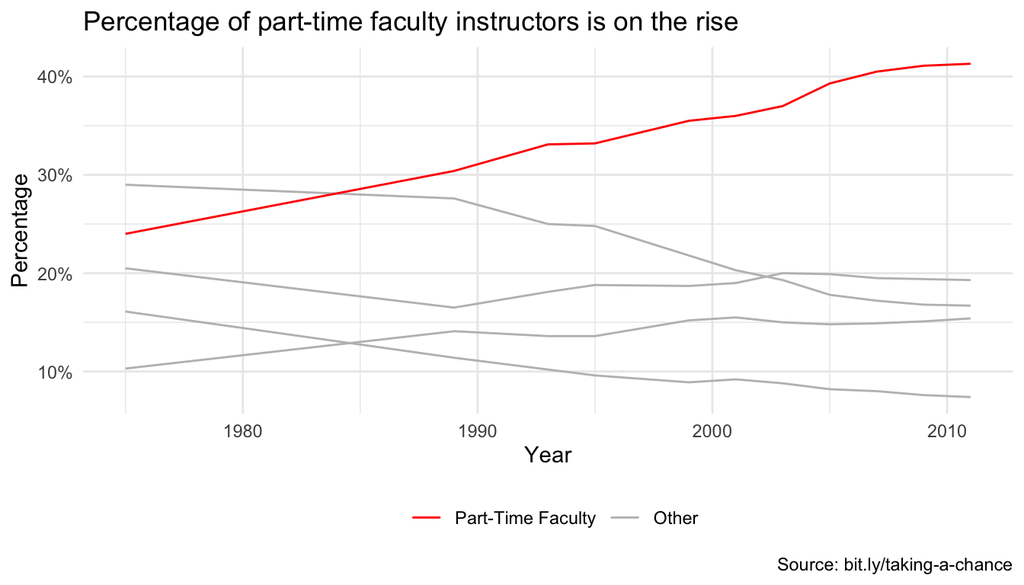

```r
library(scales)
p +
  scale_y_continuous(labels = percent_format(accuracy = 1)) + # 1
  labs( # 2
    title = "Percentage of part-time faculty instructors is on the rise",
    x = "Year",
    y = "Percentage",
    caption = "Source: bit.ly/taking-a-chance",
    color = ""
  ) +
  theme_minimal() + # 3
  theme(legend.position = "bottom") # 4
```

## Similar exercises

### Electric skateboars

[figure not shown]

Figure 3: Comparison of specifications for electronic skateboards.

The data for used to create this plot may be found at bit.ly/chance-skateboard. A class activity / assignment around this example should begin by having the students list of all the variables included in this visualisation and how they are displayed in the scatterplot:

- Relationship between the top speed and the range (points on x and y axis)
- Manufacturer (colour of points)
- Weight of electronic skateboard (size of point)
- Type of drive (dotted vs. solid line on point)
- Name of electronic skateboard (labels for each point)

Figure 4 shows the evolution of visualisations we can make in improving this plot. The most clear information we get from this visualization is the relationship between the top speed and the range. Therefore, we can start by making a plot that just examines the relationship between these two variables (Plot I). Then, we add colour to add information on weights (Plot II), and finally, we can use we can facet the plot based on the drive (belt vs. hub/direct) as well as use proper labels and an informative title (Plot III).

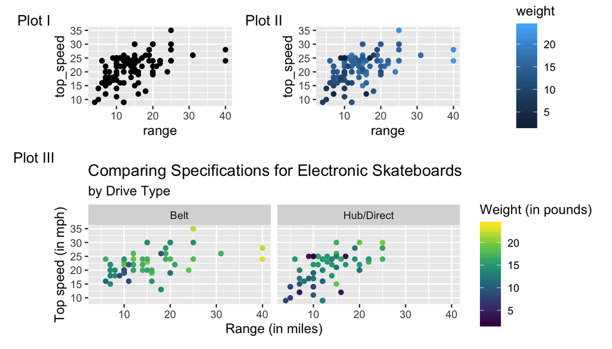

Figure 4: Plot I: Top speed vs. range, 2. Plot II: I + coloring by weight, 3. Plot III: II + faceting anf formatting

### Fisheries of the world

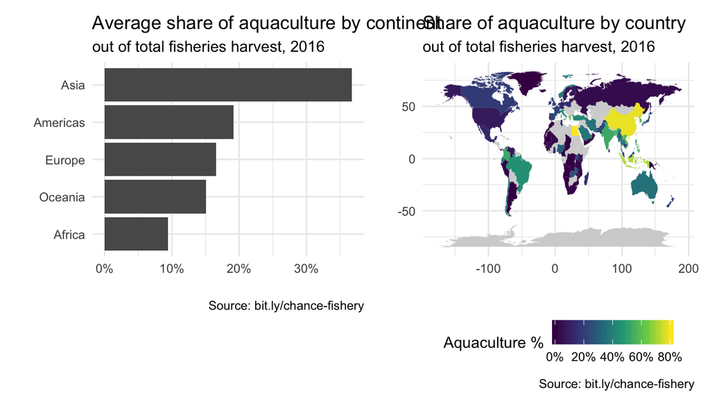

## Further reading

1. Wickham et al., (2019). Welcome to the tidyverse. Journal of Open Source Software, 4(43), 1686, https://doi.org/10.21105/joss.01686.
2. “Fishing industry by country.” Wikipedia, Wikimedia Foundation, 12 February 2020, en.wikipedia.org/wiki/Fishing_industry_by_country.